# Correlation and covariance

Joshua Loftus

#### Outline

- Covariance: interaction between variables
- Correlation: standardized covariance
- Summarizing two continuous variables
- Things to worry about

## Covariance

- Until this point we’ve focused on methods studying one variable (at a time), or *independent* and identically distributed samples of one random variable
- Now we’ll start considering relationships between two variables, and dependence
- Here’s an example plot to get a visual idea about what we’re doing:

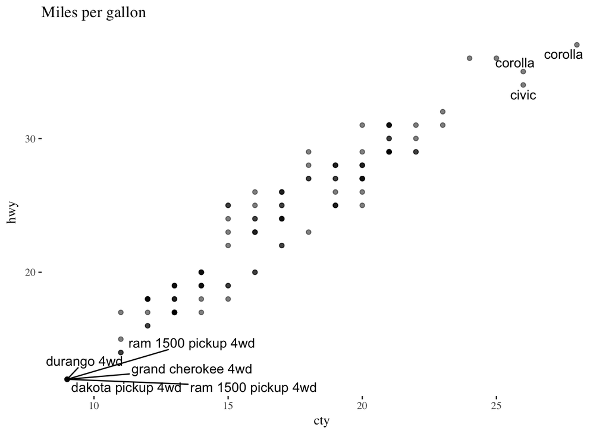

```r
mpg2008 <- filter(mpg, year == "2008")
mpgplot <- ggplot(mpg2008, aes(cty, hwy)) +
    theme_tufte() +
    ggtitle("Miles per gallon") +
    geom_text_repel(data = subset(mpg2008, cty >= 26 | cty == 9),
                      mapping = aes(label = model))
mpgplot + geom_point(alpha = .5)
```

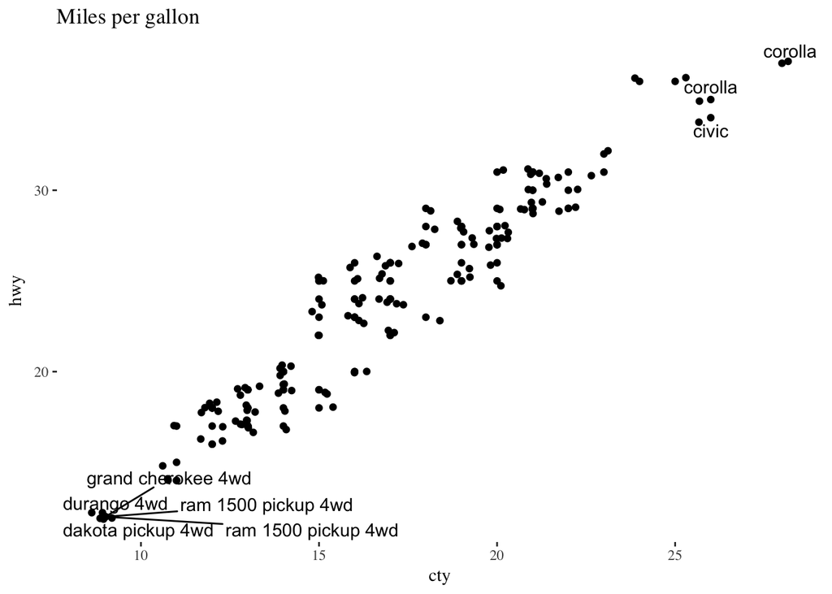

```r
mpgplot + geom_point() + geom_jitter()
```

### Mathematical background

- We’ll start with a bit of math and then move to data, interpretation, more plots, etc
- Think about two random variables, $X$ and $Y$.
- **Covariance** measures how they vary together:
  $$\text{Cov}(X, Y) = E[(X- E[X])(Y - E[Y])]$$
- Roughly speaking:
- If larger values of $X$ occur together with larger values of $Y$, their covariance is positive
- If larger values of $X$ occur with smaller values of $Y$, their covariance is negative
- What is $\text{Cov}(Y,X)$? (symmetry)
- What is $\text{Cov}(X,X)$? ($\text{Var}(X)$)
- If $E[X] = E[Y] = 0$, then $\text{Cov}(X,Y) = E[XY]$
- What if we add a consant to $X$, what happens to the covariance?
- Variance of a sum involves covariance:
  $$\text{Var}(X + Y) = \text{Var}(X) + 2\text{Cov}(X,Y) + \text{Var}(Y)$$
- Does this formula remind you of something in algebra? $(x+y)^2 = x^2 + 2xy + y^2$ (not a coincidence!)

### Calculating from samples of data

- Covariance between two random variables can be thought of as another unknown parameter
- We now focus on calculating the **sample covariance** when we have data
- (This is another example of using the plug-in principle to estimate an unknown parameter)
- The data has to come in pairs: $(X_1, Y_1), (X_2, Y_2), \ldots, (X_n, Y_n)$.
- One way of thinking about this is that it makes sense to put them in columns next to each other in the same spreadsheet
- Remember the paired $t$-test for a difference in means? Similarly, it makes sense if observations of $X$ and $Y$ are measuring two aspects of one underlying thing, like city and highway mpg for the same car, or expenses and earnings for the same company
- If the two variables aren’t measured in pairs like this, we can’t calculate covariance
- The sample covariance formula is
  $$\text{cov(X,Y)} = \frac{1}{n-1} \sum_{i=1}^n (x_i - \bar x)(y_i - \bar y)$$
- In spreadsheet terms: first center each variable by subtracting its mean, then multiply the two centered variables together, then take the average of that product
- Example using `R` functions for covariance:

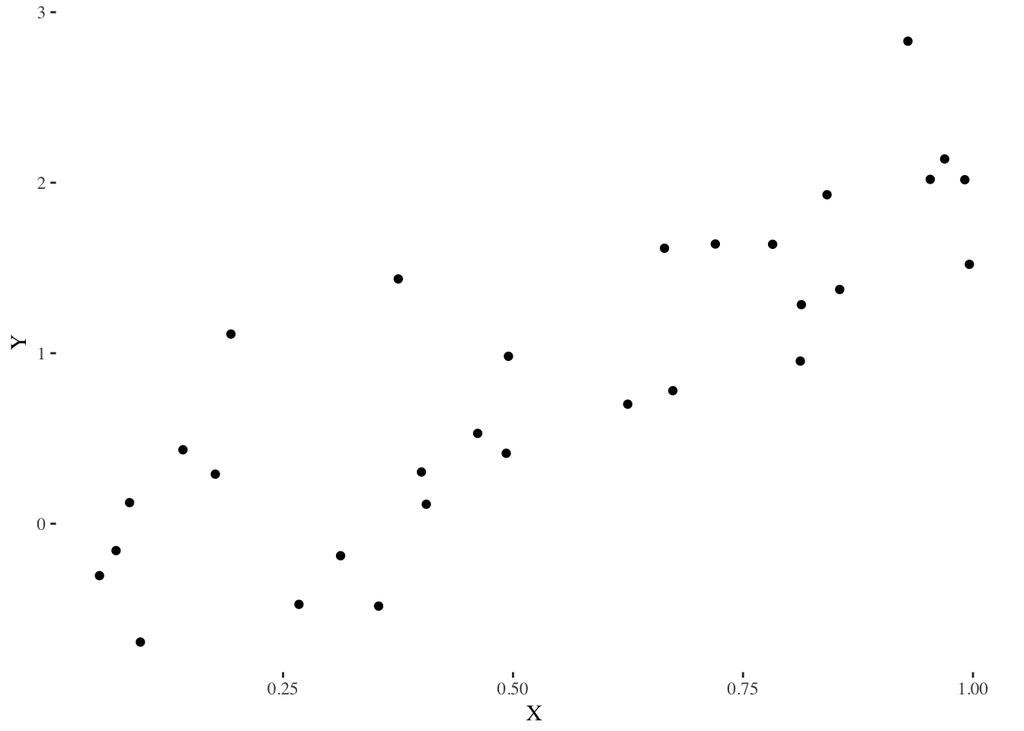

```r
n <- 30
X <- runif(n)
Y <- 2*X^2 + .5*rnorm(n)
# Scatterplot
qplot(X, Y) + theme_tufte()
```

```r
# Calculate covariance
X_centered <- X - mean(X)
Y_centered <- Y - mean(Y)
XY_centered_product <- X_centered * Y_centered
sum(XY_centered_product)/(n-1)
```

```
## [1] 0.2410011
```

```r
# Check our answer with R's built in covariance function
cov(X,Y)
```

```
## [1] 0.2410011
```

```r
# Check the variance summation formula
var(X+Y)
```

```
## [1] 1.415678
```

```r
var(X) + 2*cov(X,Y) + var(Y)
```

```
## [1] 1.415678
```

- Covariance of the mpg data:

```r
cov(mpg2008$cty, mpg2008$hwy)
```

```
## [1] 22.86944
```

- In summary, covariance measures how two variables change together
- We’ll get better interpretability by standardizing, which is what we do next

## Correlation

### Standardization

- Covariance depends on the scale, or units, of $X$ and $Y$
- For example: $\text{Cov}(aX, bY) = ab \text{Cov}(X,Y)$
- To get a scale-free version, we standardize $X$ and $Y$ by their standard deviations
- Write $\sigma_X$ and $\sigma_Y$ for the standard deviations, e.g. $\sigma_X = \sqrt{E[(X-E[X])^2]}$.
- The **correlation** between $X$ and $Y$ is
  $$\text{Cor}(X,Y) = \frac{\text{Cov}(X,Y)}{\sigma_X \sigma_y}$$
- Correlation is always between plus and minus one: $-1 \leq \text{Cor}(X,Y) \leq 1$.
- Like covariance, if it is positive it means $X$ and $Y$ both increase together, and if it is negative it means one decreases as the other increases
- The closer correlation is to 1 or -1, the closer the relationship between $X$ and $Y$ is to a perfectly straight line

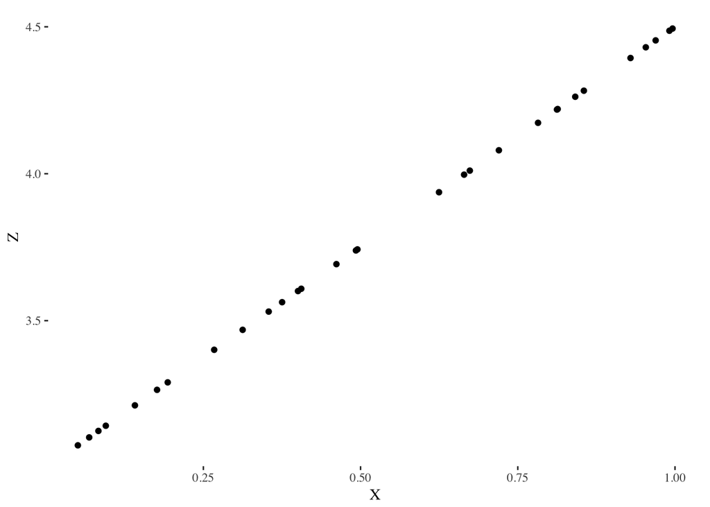

```r
Z <- 1.5 * X + 3
qplot(X, Z) + theme_tufte()
```

```r
cor(X, Z)
```

```
## [1] 1
```

- See these [interesting examples](https://en.wikipedia.org/wiki/Pearson_correlation_coefficient#/media/File:Correlation_examples2.svg) for more intuition

### Calculating the sample version

- First, standardize each variable (e.g. $x$) by subtracting its mean ($\bar x$) and dividing by its sample standard deviation ($s_x$)
- Then calculate the covariance of the standardized variables

$$\text{cor}(X,Y) = \frac{1}{n-1} \sum_{i=1}^n \left(\frac{x_i - \bar x}{s_x} \right)\left(\frac{y_i - \bar y}{s_y} \right)$$

- Example code verifying this formula with the `R` function `cor`

```r
n <- length(X)
X_standarized <- (X - mean(X))/sd(X)
Y_standarized <- (Y - mean(Y))/sd(Y)
sum(X_standarized * Y_standarized)/(n-1)
```

```
## [1] 0.8341907
```

```r
cor(X,Y)
```

```
## [1] 0.8341907
```

```r
cov(X_standarized, Y_standarized)
```

```
## [1] 0.8341907
```

## Summarizing data

- If we have a sample that measures two variables, we could summarize them by reporting their means, standard deviations, and correlation
- Is that a good idea though?… (see next section)

## Things to worry about

### Is covariance/correlation meaningful?

- Both covariance and correlation can be misleading if they are used for random variables or data that has either of the following issues
- **Non-linear** relationships

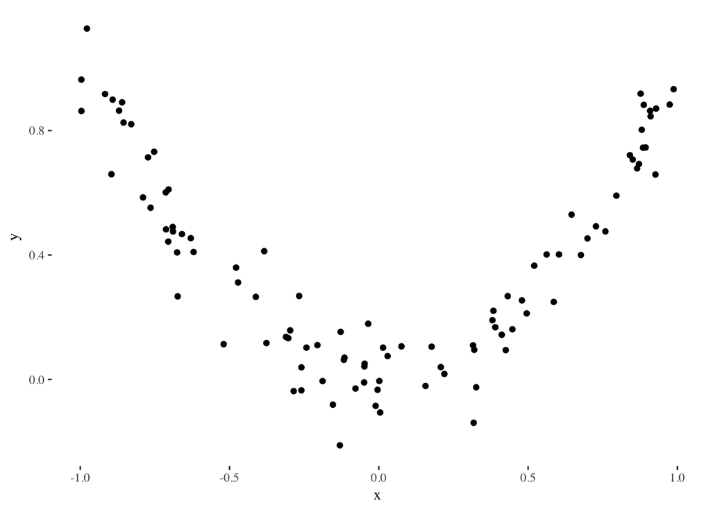

```r
n <- 100
x <- runif(n, min = -1, max = 1)
nonlinear <- data.frame(x=x, y = x^2 + .1*rnorm(n))
ggplot(nonlinear, aes(x, y)) + geom_point() + theme_tufte()
```

```r
# Is the (linear) correlation a meaningful summary of this relationship?
cor(nonlinear$x, nonlinear$y)
```

```
## [1] -0.003553514
```

- Highly **non-normal distributions**, i.e. if means aren’t useful summaries (e.g. very skewed or multimodal distributions)

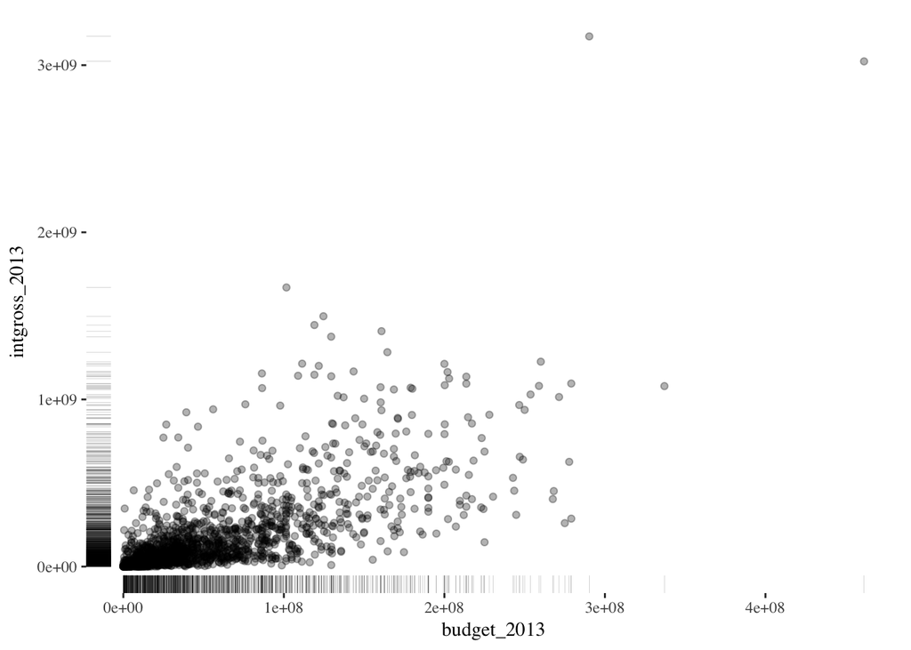

```r
movies <- bechdel[complete.cases(bechdel),]
ggplot(movies, aes(budget_2013, intgross_2013)) +
  geom_point(alpha = .3) +
  geom_rug(size = .1, alpha = .3) +
  theme_tufte()
```

```r
with(movies, cor(budget_2013, intgross_2013))
```

```
## [1] 0.6934233
```

- We can still calculate covariance and correlation, but they just don’t have the same intuition meaning or interpretation in these cases

# Take home message: always plot the data